# Loan Data from Prosper

## Preliminary Wrangling

This data set contains 113,937 loans with 81 variables on each loan, including loan amount, borrower rate (or interest rate), current loan status, borrower income, and many others.

### Here is some questions We are trying to answer:

##### What factors affect a loan’s outcome status?

##### What affects the borrower’s APR or interest rate?

##### Are there differences between loans depending on how large the original loan amount was?

##### Prosper Loan Data - important Variable Definitions:

- ListingCreationDate : The date the listing was created.
- CreditGrade : The Credit rating that was assigned at the time the listing went live. Applicable for listings pre-2009 period and will only be populated for those listings.
- Term : The length of the loan expressed in months.
- BorrowerAPR : The Borrower's Annual Percentage Rate (APR) for the loan.
- BorrowerRate : The Borrower's interest rate for this loan.
- LenderYield : The Lender yield on the loan. Lender yield is equal to the interest rate on the loan less the servicing fee.
- ProsperScore : A custom risk score built using historical Prosper data. The score ranges from 1-10, with 10 being the best, or lowest risk score. Applicable for loans originated after July 2009.
- ProsperRating (Alpha) : The Prosper Rating assigned at the time the listing was created between AA - HR. Applicable for loans originated after July 2009.
- CreditScoreRangeLower : The lower value representing the range of the borrower's credit score as provided by a consumer credit rating agency.The lower value representing the range of the borrower's credit score as provided by a consumer credit rating agency.
- LoanOriginationDate: The date the loan was originated.

### Let's start with features that highly affect loans completion in the dataset

##### Iets start by looking at the distribution of LoanStatus in our dataset

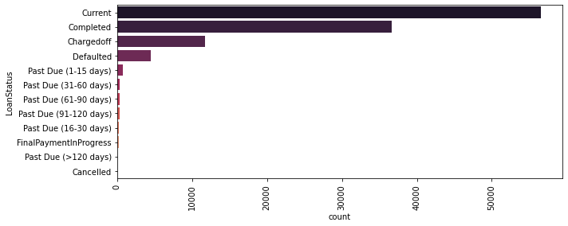

As we can see from the Bar Chart that the number of completed loans is the second higher number after current, which reflects that most of the clients that requested a loan are able to complete it.

### Lets check some Bivariate Relationships

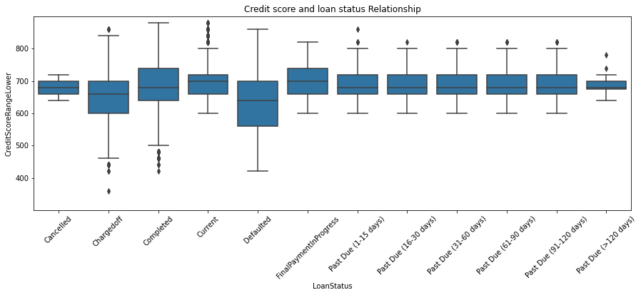

The box chart shows that the Charged off and defaulted status has a lower credit score, what is actually make sence.

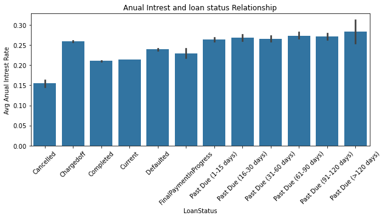

The error bar chart shows that the clients with past due greater than 120 days have the higher intrest rate

### Lets check some Multivariate Relationships

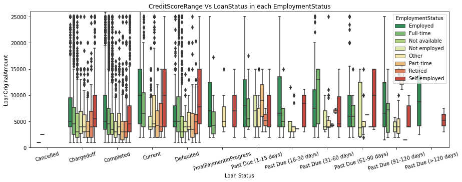

As we can see the employed,full-time and self employed has the higher loan original amount rang.

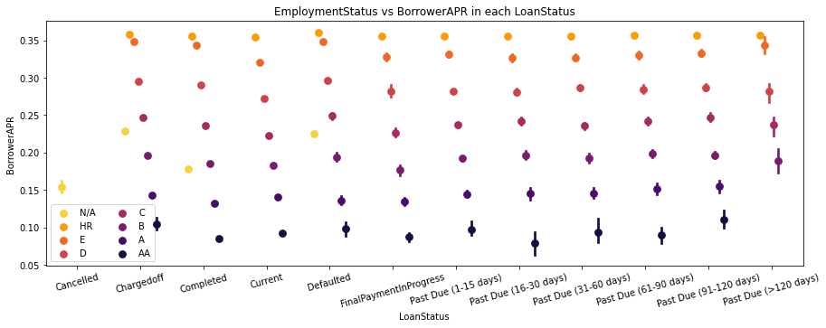

As we can see the High risk and E prosper rating clients have the highest annual interest rate, and also noticed that the clients with A and AA rating have the lowest annual interest rate.

### Talk about some of the relationships you observed in this part of the investigation. How did the feature(s) of interest vary with other features in the dataset?

According to LoanStatus distribution in our dataset:

- The number of current and completed loans are the higher count numbers in the data set, which reflects that most of the clients that requested a loan are able to complete it.
- Also noticed that the Chargedoff and defaulted are the third and forth in our data set what reflects that those clients found dificulities to pay there loan amount

According to Bivariate Relationships:

- The Charged off and defaulted status have a lower credit score,the Current and completed have a higher credit score what is acctually makes sence as your credit rate got affected when you past dued your loan payment

According to Multivariate Relationships:

- As we can see the High risk and E prosper rating clients have the highest annual interest rate, and also noticed that the clients with A and AA rating have the lowest annual interest rate.
- The clients with employed,full-time and self employed EmploymentStatus has the higher loan original amount rang what reflects the apilty for paying high loans.

### Let's check how features affects the intrest rate

##### I'll start by looking at the distribution of Intres Rate.

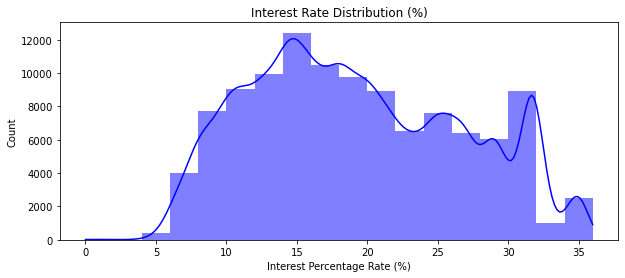

As we ca see from the histogram that the Interest Rate is normally distributed with the peak between 14 and 18 percent in addition we have some increase in the 35 percent

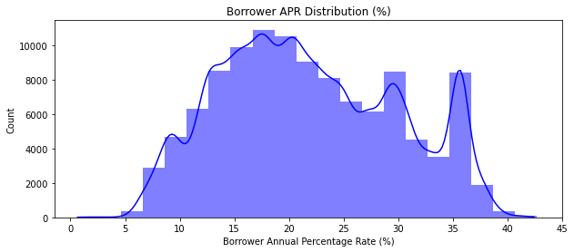

As we can see from the histogram that the Inetrest Rate is normally distrubuted with the peak between 15 and 20 percent.

### Lets check some Bivariate Relationships

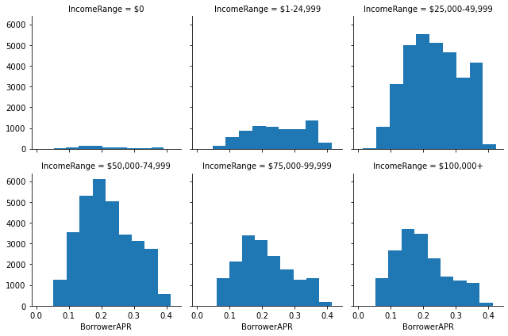

The charts shows the higher the Income Range the lower the Annual Interest rate

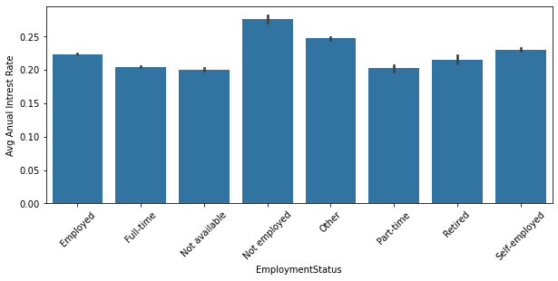

The Bar plot shows that the unemployed client has the higher intrest rate

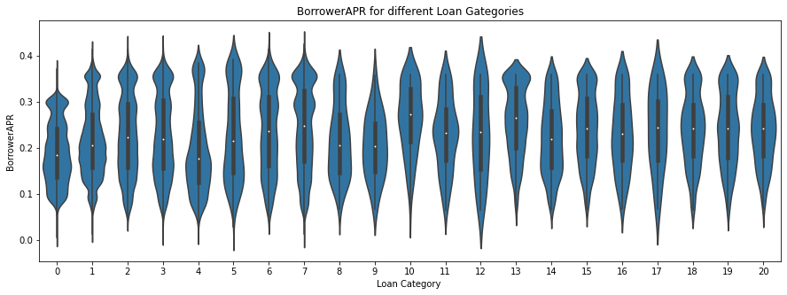

We can see that Cosmetic Procedure are given higer interest rates with data distributed well in it. Listing Category: The category of the listing that the borrower selected when posting their listing: 0 - Not Available, 1 - Debt Consolidation, 2 - Home Improvement, 3 - Business, 4 - Personal Loan, 5 - Student Use, 6 - Auto, 7- Other, 8 - Baby&Adoption, 9 - Boat, 10 - Cosmetic Procedure, 11 - Engagement Ring, 12 - Green Loans, 13 - Household Expenses, 14 - Large Purchases, 15 - Medical/Dental, 16 - Motorcycle, 17 - RV, 18 - Taxes, 19 - Vacation, 20 - Wedding Loans

### Lets check some Multivariate Relationships

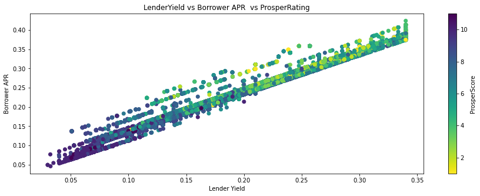

We can see that the relationship between all variables are clear. Borrower APR and Lender yield are directly positively correlated as when the interest borrowers pays more , the lender yield will increase. Higher the prosper score lower will lower borrower apr and then the lender yield will also be lower.

### Talk about some of the relationships you observed in this part of the investigation. How did the feature(s) of interest vary with other features in the dataset?

According to LoanStatus distribution in our dataset:

- As we ca see from the histogram that the Interest Rate is normally distributed with the peak between 14 and 18 percent in addition we have some increase in the 35 percent
- As we can see from the histogram that the Inetrest Rate is normally distrubuted with the peak between 15 and 20 percent, also noticed that the peak of APR higher than Intrest rate peak that is because the APR includes not only the interest expense on the loan but also all fees and other costs involved in procuring the loan.

According to Bivariate Relationships:

- The higher the Income Range the lower the Annual Interest rate, what is acctually reflecte the trust between the lender and the borrower.
- The unemployed client has the higher intrest rate, what is acctually reflecte the untrusted relationship between the lender and the borrower.
- Cosmetic Procedure are given higer interest rates with data distributed well in it.

According to Multivariate Relationships:

- We can see that the relationship between all variables are clear. Borrower APR and Lender yield are directly positively correlated as when the interest borrowers pays more , the lender yield will increase. Higher the prosper score lower will lower borrower apr and then the lender yield will also be lower.

### Let's check how features affects the original loan amount

##### I'll start by looking at the distribution of original loan amount.

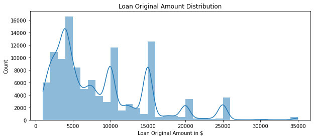

Histogram shows that the distribution is right skewed with a long tail so I will try it in the log scale to see it more better

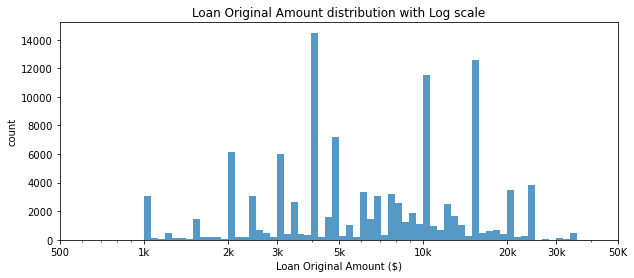

The highest value for original loan amount is between 3K and 5K. Also noticed an increase in the loan amount between 10K and 20K

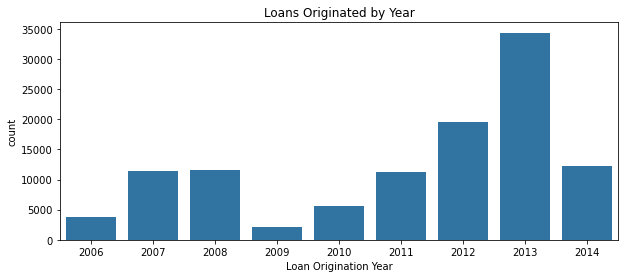

We can see from the Bar chart that there is a drop in 2009 in loans but it started to increase gradually and reached it's peak at 2013

### Lets check some Bivariate Relationships

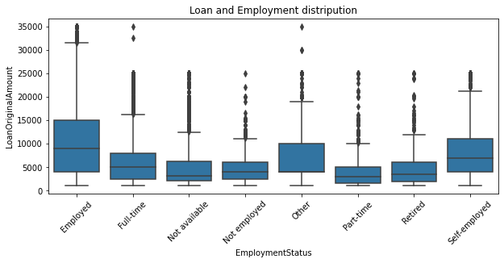

The cat chart showes that the employed clients have the higher loan original amount, also noticed few people with full time and Other have high loan original amount

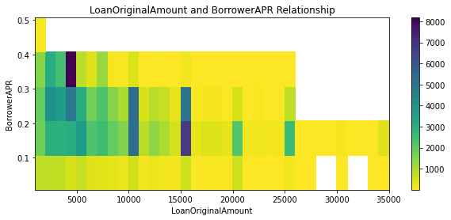

Heat map shows us the higher the loan original amount the lower the interest rate.

### Lets check some Multivariate Relationships

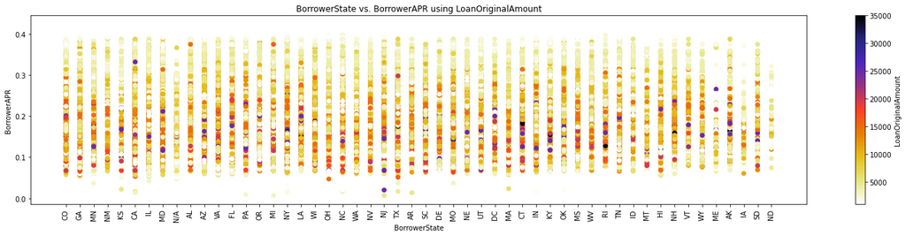

- As we can see the highest loan original amount with highest interest annual rate existed in California state
- The highest loan original with lowest intrest annual rate existed in new jersey state

### Talk about some of the relationships you observed in this part of the investigation. How did the feature(s) of interest vary with other features in the dataset?

According to Bivariate Relationships:

- The higher the loan original amount the lower the interest rate.
- the employed clients have the higher loan original amount, also noticed few people with full time and Other have high loan original amount.

### There is another interesting univariate interactions between features that I would like present

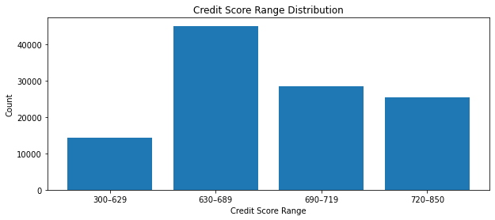

Bar charts shows that credit score limit ranges from 630 to 690 has the higher counts number

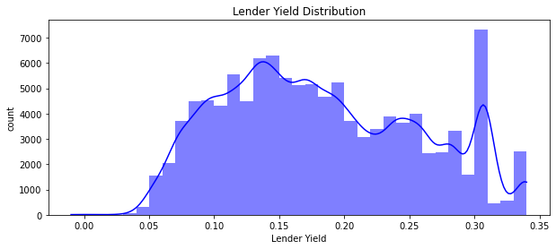

The Histogram shows that the annual net profit that an investor earns ranges between 0.1 and 0.2 and we notice an increase at 0.3 also.

I'll now continue investigate the features that I decided to focus on.

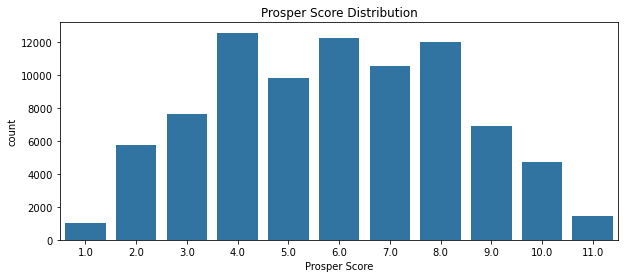

The Bar chart shows that most of the clients has a custom risk score ranges between 4 to 8

I'll now continue investigate the features that I decided to focus on.

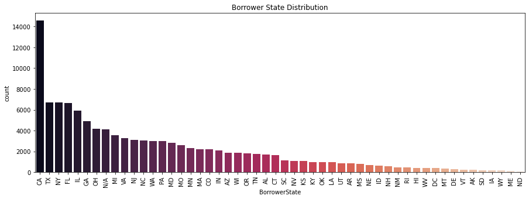

Bar chart shows that California (CA) has the highest numbers of loans across the states.

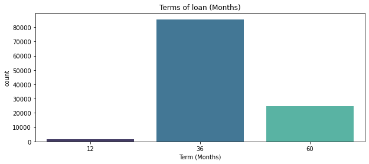

Bar chart shows that most of the clients prefer the length of the loan to be 3 years (36 months).

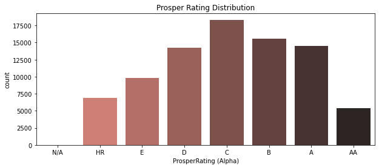

The Bar charts shows that most borrowers get Prosper Rating of 'C'

### There is another interesting univariate interactions between features that I would like present

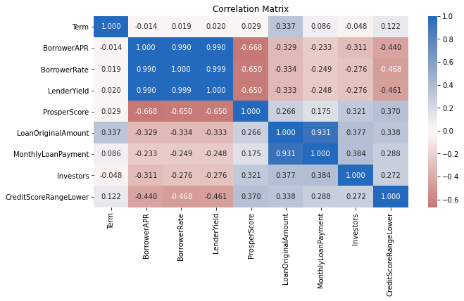

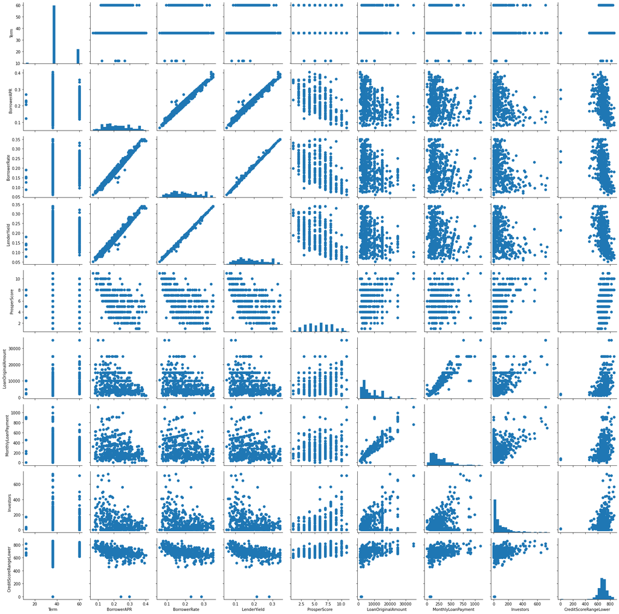

Negative correlation between prosper score & APR, and prosper score & Lender yield and criedt score range & borrower rate. Negative correlation between prosper ratings & APR, and prosper score & Lender yield.